# Examples of map layers

The following are some examples of maps produced with `mymap=openmap(x, path="something")`

# osm

`plot(openmap(x,path="osm"))`

© [OpenStreetMap](http://openstreetmap.org/copyright) contributors. Data by [OpenStreetMap](http://openstreetmap.org), available under the [Open Database License](http://opendatacommons.org/licenses/odbl), cartography is licensed as [CC BY-SA](http://creativecommons.org/licenses/by-sa/2.0).

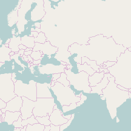

[figure not shown]

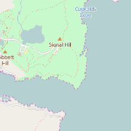

# osm-admin

`plot(openmap(x,path="osm-admin"))`

© [OpenStreetMap](http://openstreetmap.org/copyright) contributors. Data by [OpenStreetMap](http://openstreetmap.org), available under the [Open Database License](http://opendatacommons.org/licenses/odbl), cartography is licensed as [CC BY-SA](http://creativecommons.org/licenses/by-sa/2.0).

[figure not shown]

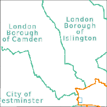

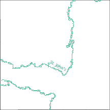

# osm-roads-grey

`plot(openmap(x,path="osm-roads-grey"))`

© [OpenStreetMap](http://openstreetmap.org/copyright) contributors. Data by [OpenStreetMap](http://openstreetmap.org), available under the [Open Database License](http://opendatacommons.org/licenses/odbl), cartography is licensed as [CC BY-SA](http://creativecommons.org/licenses/by-sa/2.0).

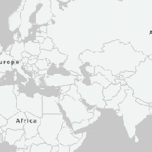

[figure not shown]

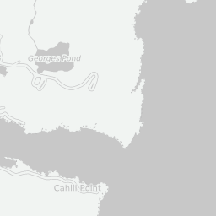

# osm-roads

`plot(openmap(x,path="osm-roads"))`

© [OpenStreetMap](http://openstreetmap.org/copyright) contributors. Data by [OpenStreetMap](http://openstreetmap.org), available under the [Open Database License](http://opendatacommons.org/licenses/odbl), cartography is licensed as [CC BY-SA](http://creativecommons.org/licenses/by-sa/2.0).

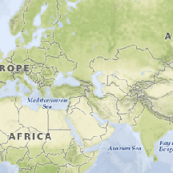

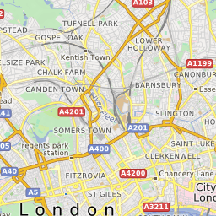

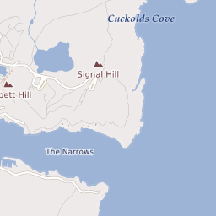

# osm-semitransparent

`plotRGB(openmap(x,path="osm-semitransparent"))`

© [OpenStreetMap](http://openstreetmap.org/copyright) contributors. Data by [OpenStreetMap](http://openstreetmap.org), available under the [Open Database License](http://opendatacommons.org/licenses/odbl), cartography is licensed as [CC BY-SA](http://creativecommons.org/licenses/by-sa/2.0).

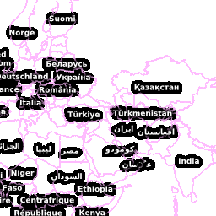

[figure not shown]

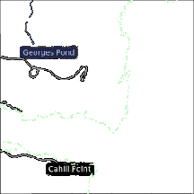

# osm-no-labels

`plot(openmap(x,path="osm-no-labels"))`

© [OpenStreetMap](http://openstreetmap.org/copyright) contributors. Data by [OpenStreetMap](http://openstreetmap.org), available under the [Open Database License](http://opendatacommons.org/licenses/odbl), cartography is licensed as [CC BY-SA](http://creativecommons.org/licenses/by-sa/2.0).

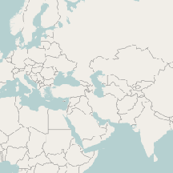

[figure not shown]

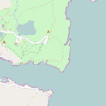

# osm-de

`plot(openmap(x,path="osm-de"))`

© [OpenStreetMap](http://openstreetmap.org/copyright) contributors. Data by [OpenStreetMap](http://openstreetmap.org), available under the [Open Database License](http://opendatacommons.org/licenses/odbl), cartography is licensed as [CC BY-SA](http://creativecommons.org/licenses/by-sa/2.0).

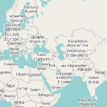

[figure not shown]

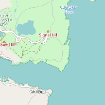

# osm-transport

`plot(openmap(x,path="osm-transport"))`

© [OpenStreetMap](http://openstreetmap.org/copyright) contributors. Data by [OpenStreetMap](http://openstreetmap.org), available under the [Open Database License](http://opendatacommons.org/licenses/odbl), cartography is licensed as [CC BY-SA](http://creativecommons.org/licenses/by-sa/2.0).

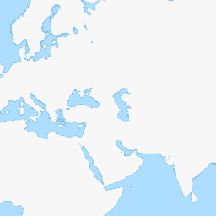

[figure not shown]

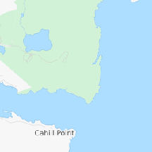

# bw-mapnik

`plot(openmap(x,path="bw-mapnik"))`

© [OpenStreetMap](http://openstreetmap.org/copyright) contributors. Data by [OpenStreetMap](http://openstreetmap.org), available under the [Open Database License](http://opendatacommons.org/licenses/odbl), cartography is licensed as [CC BY-SA](http://creativecommons.org/licenses/by-sa/2.0).

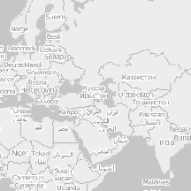

[figure not shown]

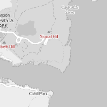

# mapquest

`plotRGB(openmap(x,path="mapquest"))`

Tiles courtesy of [MapQuest](http://www.mapquest.com). Data by [OpenStreetMap](http://openstreetmap.org), available under the [Open Database License](http://opendatacommons.org/licenses/odbl)

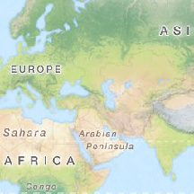

[figure not shown]

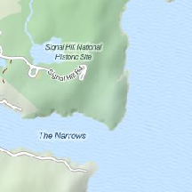